# Pregnancy exposure to phenols and anthropometric measures in gestation and at birth

Main analyses

Paulina Jedynak, Matthieu Rolland, Isabelle Pin, Cathrine Thomsen, Amrit K. Sakhi, Azemira Sabaredzovic, Claire Philippat, Rémy Slama, and the SEPAGES study group

2022

Abstract

Background: Some synthetic phenols alter pathways involved in fetal development. Despite their high within-subject temporal variability, earlier studies relied on spot urine samples to assess pregnancy exposure. In this study, we examined associations between prenatal phenol exposure and fetal growth. Methods: We measured concentrations of two bisphenols, four parabens, benzophenone-3, and triclosan in 478 pregnant women in two weekly pools of 21 samples each, collected at 18 and 34 gestational weeks. We used adjusted linear regressions to study associations between phenol concentrations and growth outcomes assessed twice during pregnancy and at birth. Results: Benzophenone-3 was positively associated with all ultrasound growth parameters in at least one time point, in males but not females. In females, butylparaben was negatively associated with third trimester abdominal circumference and weight at birth. We observed isolated associations for triclosan (negative) and for methylparaben and bisphenol S (positive) and late pregnancy fetal growth. Conclusions: Our results suggest associations between prenatal exposure to phenols and fetal growth. Benzophenone-3 was the exposure most consistently (positively) associated across all growth parameters.

## **General setup**

```r
knitr::opts_chunk$set(echo = TRUE)
```

```r
# Create a path to save output files
path_main <- "results/phenols" # main analyses of the paper
```

## **Load packages and functions**

```r
# Load packages
library("tidyverse")
source("R/UsoundDataCreation.R")
source("R/DataPreparation.R")
source("R/DescriptiveAnalysis.R")
source("R/Figures.R")
source("R/StatModels.R")
```

## **Load datasets**

```r
# Load datasets
# Information on the anthropometric measures
bdd_grossesse <- haven::read_stata(here::here("data/raw_data/bdd_grossesse_v4_1.dta")) # replaced the old database bdd_grossesse_v4.dta with a new version provided by Karine Supernant

samples <- readr::read_csv(here::here("data/raw_data/phenols_phthalates_pregnancy_mr_2020-03-26_448.csv")) # sent by Claire Philippat 26/02/2021 by email

tobacco <- haven::read_stata(here::here("data/raw_data/tobaccopregnancy_ag_20201218_16_copy.dta")) %>%
  dplyr::mutate(ident = as.character(ident)) # produced by Ariane Guilbert in December 2020 and sent by her by email 22/02/2021

ultrasound_manual <- haven::read_stata(here::here("data/raw_data/donnees_echo_saisies_quest_mt1caj1.dta")) # we confirmed with Sarah Lyon-Caen 25/02/2021 on Slack, that this is the final dataset

limits <- readr::read_csv(here::here("data/raw_data/limits_data_2022-01-24.csv")) # sent by Matthieu Rolland
```

## **Prepare variable lists**

Manually created lists of compounds, models variables, etc.

```r
# Manually create the variables names
# Full names of exposure variables
exposures_long <- c("Bisphenol A", "Bisphenol S", "Triclosan", "Benzophenone-3", "Butylparaben", "Ethylparaben", "Methylparaben", "Propylparaben")

# Full names of continuous exposure variables
exposures_long_nocat <- c("Bisphenol A", "Triclosan", "Benzophenone-3", "Ethylparaben", "Methylparaben", "Propylparaben")

# Full names of categorical exposure variables
exposures_long_cat <- c("Bisphenol S", "Butylparaben")

# Short names of exposure variables as used in the databases
expo_names <- c("log_BPA", "log_TCS", "log_BP3", "log_ETPA", "log_MEPA", "log_PRPA", "cat_BPS", "cat_BUPA")

# Short names of exposures that do not include not standardized exposures (TCS, BUPA and BPS)
expo_names_nosd <- c("log_BPA", "log_BP3", "log_ETPA", "log_MEPA", "log_PRPA")
```

## **Data preparation**

```r
# Extract individuals' IDs
id_list <- samples %>%
  pull(ident) %>%
  unique() %>%
  sort()

# * Create population characteristics data ---- 479 x 9
pop_data <- CreatePopData(covariates_data = bdd_grossesse,
                          expo_data = samples)

# * Create tobacco data ---- 484 x 2
smoke_data <- CreateSmokeData(tobacco_data = tobacco)

# * Create birth outcomes data ---- 1,437 x 5
birth_data <- CreateBirthOutcomes(covariates_data = bdd_grossesse,
                                  pop_data = pop_data)

# * Create exposure data ---- 479 x 49
expo_data <- CreateExpoData(expo_data = samples)

# * Create ultrasound data ---- 4,604 x 11
ultrasound_long <- CreateUsoundDdata(bdd_grossesse = bdd_grossesse,
                                     ultrasound_manual_data = ultrasound_manual)
```

```r
# * Create population, smoking and exposure dataset ---- 479 x 58
pop_smoke_expo_miss <- pop_data %>%
  left_join(smoke_data, by = "ident") %>%
  left_join(expo_data, by = "ident")

# Save dataset for sensitivity analyses
saveRDS(pop_smoke_expo_miss, here::here(path_main, "pop_smoke_expo_miss.RDS"))

pop_smoke_expo <- ImputeMissingCov(data_w_missing = pop_smoke_expo_miss)

# Save dataset for sensitivity analyses
saveRDS(pop_smoke_expo, here::here(path_main, "pop_smoke_expo.RDS"))

# *  Create all outcomes data ---- 4,933 x 11
# All outcomes for patients with at least one sample and T2 and T3 (not T1)
outcomes_long <- bind_rows(birth_data, ultrasound_long) %>%
  filter(ident %in% id_list & trimester != "US1") %>%
  filter(keep_flag | trimester == "birth")

# * Create model data ---- 4,933 x 68
model_data <- outcomes_long %>%
  left_join(pop_smoke_expo, by = "ident") %>%

  # standardise outcome vals
  dplyr::group_by(outcome, trimester) %>%
  dplyr::mutate(outcome_val_sd = outcome_val / sd(outcome_val, na.rm = TRUE)) %>%
  dplyr::ungroup()

# Save the output for sensitivity analysis
saveRDS(model_data, here::here(path_main, "model_data.RDS"))
```

```r
# Define continues exposure variables to be transformed to long format ---- n = 28
cols_to_long_cont <- ColsToLong(x = expo_names[!str_detect(expo_names, "cat")],
                                y = expo_names_nosd[!str_detect(expo_names_nosd, "cat")])

# Define continues exposure variables to be transformed to long format ---- n = 6
cols_to_long_cat <- ColsToLong(x = expo_names[str_detect(expo_names, "cat")])

# Create dataset in a long format for continues exposure variables ---- 138,124 x 18
model_data_long_cont <- ModelDataAllVarsLong(model_data = model_data,
                                             cols_to_long = cols_to_long_cont)

# Save the output for sensitivity analysis
saveRDS(model_data_long_cont, here::here(path_main, "model_data_long_cont.RDS"))

# Create dataset in a long format for categorical exposure variables ---- 29,598 x 18
model_data_long_cat <- ModelDataAllVarsLong(model_data = model_data,
                                            cols_to_long = cols_to_long_cat)

# Remove non-standardized exposures, T2&T3 averaged exposure predicting T2, and T2 exposure predicting T3 and birth
model_data_long_main_cont <- RemoveConditions(model_data_long_cont) # 29,598 x 18
model_data_long_main_cat <- RemoveConditions(model_data_long_cat) # 9,866 x 18

# Save the outputs for sensitivity analysis
saveRDS(model_data_long_main_cont, here::here(path_main, "model_data_long_main_cont.RDS"))
saveRDS(model_data_long_main_cat, here::here(path_main, "model_data_long_main_cat.RDS"))
```

## **Population characteristics**

```r
# Print population characteristics
(pop_char <- PopulationCharacteristics(
  cov_expo_data = pop_smoke_expo_miss,
  path = path_main,
  file_name = "population_characteristics"))
```

```
##
## --------Summary descriptives table ---------
##
## __________________________________________________________
##                                            [ALL]        N
##                                            N=478
## ¯¯¯¯¯¯¯¯¯¯¯¯¯¯¯¯¯¯¯¯¯¯¯¯¯¯¯¯¯¯¯¯¯¯¯¯¯¯¯¯¯¯¯¯¯¯¯¯¯¯¯¯¯¯¯¯¯¯
## Maternal weight before pregnancy (kg) 59.0 [54.0;66.0] 478
## Maternal height, cm                    165 [161;169]   474
## Maternal age at conception, years     32.1 [29.9;35.2] 478
## mom_edu:                                               478
##     Low                                  82 (17.2%)
##     Middle                              125 (26.2%)
##     High                                268 (56.1%)
##     'Missing'                            3 (0.63%)
## parity:                                                478
##     First                               219 (45.8%)
##     Second                              211 (44.1%)
##     Third_and_more                       48 (10.0%)
## child_sex:                                             478
##     Female                              220 (46.0%)
##     Male                                256 (53.6%)
##     'Missing'                            2 (0.42%)
## gestational_duration                     278 (10.8)    476
## gestational_duration_weeks            40.0 [39.0;40.7] 476
## smoke_high:                                            478
##     No                                  427 (89.3%)
##     Yes                                  11 (2.30%)
##     'Missing'                            40 (8.37%)
## ¯¯¯¯¯¯¯¯¯¯¯¯¯¯¯¯¯¯¯¯¯¯¯¯¯¯¯¯¯¯¯¯¯¯¯¯¯¯¯¯¯¯¯¯¯¯¯¯¯¯¯¯¯¯¯¯¯¯
```

## **Exposure descriptive statistics**

```r
# Exposure descriptive statistics for non standardized exposures
(exp_desc <- ExposureCharacteristics(expo_data = samples,
                                     limits = limits))
```

| compound | LOD | n_t2ns | pct_det_t2ns | p5_t2ns | median_t2ns | p95_t2ns | n_t3ns | pct_det_t3ns | p5_t3ns | median_t3ns | p95_t3ns | n_t2s | pct_det_t2s | p5_t2s | median_t2s | p95_t2s | n_t3s | pct_det_t3s | p5_t3s | median_t3s | p95_t3s |
| --- | --- | --- | --- | --- | --- | --- | --- | --- | --- | --- | --- | --- | --- | --- | --- | --- | --- | --- | --- | --- | --- |
| bpa | 0.04 | 477 | 99.4 | 0.7 | 2.0 | 8.6 | 456 | 98.0 | 0.5 | 1.8 | 9.3 | 477 | 99.6 | 0.6 | 1.6 | 7.2 | 456 | 98.2 | 0.4 | 1.4 | 6.9 |
| bps | 0.10 | 477 | 25.4 | NaN | NaN | 3.0 | 454 | 28.2 | NaN | NaN | 2.9 | NA | NA | NA | NA | NA | NA | NA | NA | NA | NA |
| bp3 | 0.04 | 477 | 100.0 | 0.3 | 1.2 | 35.3 | 456 | 99.6 | 0.2 | 1.0 | 27.5 | 477 | 100.0 | 0.2 | 0.8 | 20.5 | 456 | 99.8 | 0.2 | 0.7 | 15.6 |
| tcs | 0.04 | 477 | 98.3 | 0.2 | 0.9 | 165.2 | 456 | 98.2 | 0.2 | 0.9 | 176.1 | NA | NA | NA | NA | NA | NA | NA | NA | NA | NA |
| bupa | 0.07 | 477 | 24.5 | NaN | NaN | 0.7 | 456 | 23.7 | NaN | NaN | 0.8 | NA | NA | NA | NA | NA | NA | NA | NA | NA | NA |
| etpa | 0.04 | 477 | 99.8 | 0.2 | 0.7 | 32.5 | 456 | 99.3 | 0.2 | 0.7 | 25.0 | 477 | 99.8 | 0.3 | 1.0 | 43.9 | 456 | 99.8 | 0.3 | 1.0 | 34.5 |
| mepa | 0.04 | 477 | 100.0 | 2.7 | 12.4 | 279.7 | 456 | 100.0 | 2.9 | 12.5 | 2415.3 | 477 | 100.0 | 2.7 | 13.4 | 276.7 | 456 | 100.0 | 2.6 | 13.8 | 2337.7 |
| prpa | 0.04 | 477 | 82.0 | NaN | 0.4 | 63.6 | 456 | 80.7 | NaN | 0.6 | 137.1 | 477 | 84.5 | NaN | 0.5 | 67.4 | 456 | 82.7 | NaN | 0.6 | 151.1 |

```r
# Print the detection rates per exposure per trimester
dplyr::select(exp_desc, compound, dplyr::contains("pct_")) %>%
  tidyr::pivot_longer(cols = -compound,
                      names_to = "pct",
                      values_to = "pct_val") %>%
  dplyr::mutate(pct_val = round(pct_val)) %>%
  dplyr::arrange(pct_val) # The detection rate for BUPA: 24%, BPS: 25%, rest: 81%.
```

| compound | pct | pct_val |
| --- | --- | --- |
| bupa | pct_det_t2ns | 24 |
| bupa | pct_det_t3ns | 24 |
| bps | pct_det_t2ns | 25 |
| bps | pct_det_t3ns | 28 |
| prpa | pct_det_t3ns | 81 |
| prpa | pct_det_t2ns | 82 |
| prpa | pct_det_t3s | 83 |
| prpa | pct_det_t2s | 84 |
| bpa | pct_det_t3ns | 98 |
| bpa | pct_det_t3s | 98 |

[output cut: 22 more lines]

## **Main statistical analyses**

### Main models

```r
# Run linear regressions for continuous exposures
model_output_cont <- ComputeGrowthModels(model_data_long = model_data_long_main_cont) # 66 tests x 12

model_tab_cont <- sapply(X = exposures_long_nocat,
                         FUN = PrintTab,
                         model_output = model_output_cont,
                         simplify = FALSE,
                         USE.NAMES = TRUE)

# Tidy the results
res_cont <- purrr::map_df(model_tab_cont, ~as.data.frame(.x), .id = "exposure") %>%
  dplyr::mutate(term = factor(term,
                              levels = "exp_val",
                              labels = "Continuous"))
```

```r
# Run linear regressions for categorical exposures
model_output_cat <- ComputeGrowthModels(model_data_long = model_data_long_main_cat,
                                        cat = TRUE) # 44 tests x 12

model_tab_cat <- sapply(X = exposures_long_cat,
                        FUN = PrintTab,
                        model_output = model_output_cat,
                        cat = TRUE,
                        simplify = FALSE,
                        USE.NAMES = TRUE)

# Tidy the results
res_cat <- purrr::map_df(model_tab_cat, ~as.data.frame(.x), .id = "exposure") %>%
  dplyr::mutate(term = substring(term, 8),
                term = factor(term, levels = c("LOD-LOQ", ">LOQ"))) %>%
  dplyr::arrange(exposure, tri_out, term)

# Merge the results for continuous and categorical exposures
res_combined <- dplyr::bind_rows(res_cont, res_cat)
saveRDS(res_combined, here::here(path_main, "res_combined.RDS"))
```

### Sex-specific associations

```r
# Run linear regressions for continuous exposures including interaction term between exposure and child sex
model_output_inter_cont <- ComputeGrowthModels(model_data_long = model_data_long_main_cont, sex = TRUE)

model_tab_inter_cont <- sapply(X = exposures_long_nocat, FUN = PrintTab, model_output = model_output_inter_cont, sex = TRUE, simplify = FALSE, USE.NAMES = TRUE)

# Tidy the results
res_inter_cont <- purrr::map_df(model_tab_inter_cont, ~as.data.frame(.x), .id = "exposure")
```

```r
# Run linear regressions for acegorical exposures including interaction term between exposure and child sex
model_output_inter_cat <- ComputeGrowthModels(model_data_long = model_data_long_main_cat, cat = TRUE, sex = TRUE)

model_tab_inter_cat <- sapply(X = exposures_long_cat, FUN = PrintTab, model_output = model_output_inter_cat, cat = TRUE, sex = TRUE, simplify = FALSE, USE.NAMES = TRUE)

# Tidy the results
res_inter_cat <- purrr::map_df(model_tab_inter_cat, ~as.data.frame(.x), .id = "exposure")

# Merge the results and save for sensitivity analysis
res_inter <- dplyr::bind_rows(res_inter_cont, res_inter_cat)
saveRDS(res_inter, here::here(path_main, "res_inter.RDS"))
```

## **Tables**

### TABLE 1

Characteristics of the mother-child pairs included in SEPAGES couple-child cohort study (France, 2014-2017, n = 479).

```r
Table_1 <- utils::read.csv(here::here(path_main, "population_characteristics.csv")) %>%
  as.data.frame()

colnames(Table_1) <- c("Characteristic", "Distribution", "N")

utils::write.csv(Table_1, here::here(path_main, "tables/Table_1.csv"), row.names = FALSE)
Table_1
```

| Characteristic | Distribution | N |
| --- | --- | --- |
|  | N=478 | NA |
| Maternal weight before pregnancy (kg) | 59.0 [54.0;66.0] | 478 |
| Maternal height, cm | 165 [161;169] | 474 |
| Maternal age at conception, years | 32.1 [29.9;35.2] | 478 |
| mom_edu: |  | 478 |
| Low | 82 (17.2%) | NA |
| Middle | 125 (26.2%) | NA |
| High | 268 (56.1%) | NA |
| 'Missing' | 3 (0.63%) | NA |
| parity: |  | 478 |

[output cut: 13 more lines]

### TABLE 2

Average maternal urinary phenol concentrations assessed in weekly pools collected in trimesters 2 and 3 of pregnancy, without or with standardization on sampling conditions (n = 479 pregnant women).

```r
Table_2 <- exp_desc

utils::write.csv(Table_2, here::here(path_main, "tables/Table_2.csv"), row.names = FALSE)
Table_2
```

| compound | LOD | n_t2ns | pct_det_t2ns | p5_t2ns | median_t2ns | p95_t2ns | n_t3ns | pct_det_t3ns | p5_t3ns | median_t3ns | p95_t3ns | n_t2s | pct_det_t2s | p5_t2s | median_t2s | p95_t2s | n_t3s | pct_det_t3s | p5_t3s | median_t3s | p95_t3s |
| --- | --- | --- | --- | --- | --- | --- | --- | --- | --- | --- | --- | --- | --- | --- | --- | --- | --- | --- | --- | --- | --- |
| bpa | 0.04 | 477 | 99.4 | 0.7 | 2.0 | 8.6 | 456 | 98.0 | 0.5 | 1.8 | 9.3 | 477 | 99.6 | 0.6 | 1.6 | 7.2 | 456 | 98.2 | 0.4 | 1.4 | 6.9 |
| bps | 0.10 | 477 | 25.4 | NaN | NaN | 3.0 | 454 | 28.2 | NaN | NaN | 2.9 | NA | NA | NA | NA | NA | NA | NA | NA | NA | NA |
| bp3 | 0.04 | 477 | 100.0 | 0.3 | 1.2 | 35.3 | 456 | 99.6 | 0.2 | 1.0 | 27.5 | 477 | 100.0 | 0.2 | 0.8 | 20.5 | 456 | 99.8 | 0.2 | 0.7 | 15.6 |
| tcs | 0.04 | 477 | 98.3 | 0.2 | 0.9 | 165.2 | 456 | 98.2 | 0.2 | 0.9 | 176.1 | NA | NA | NA | NA | NA | NA | NA | NA | NA | NA |
| bupa | 0.07 | 477 | 24.5 | NaN | NaN | 0.7 | 456 | 23.7 | NaN | NaN | 0.8 | NA | NA | NA | NA | NA | NA | NA | NA | NA | NA |
| etpa | 0.04 | 477 | 99.8 | 0.2 | 0.7 | 32.5 | 456 | 99.3 | 0.2 | 0.7 | 25.0 | 477 | 99.8 | 0.3 | 1.0 | 43.9 | 456 | 99.8 | 0.3 | 1.0 | 34.5 |
| mepa | 0.04 | 477 | 100.0 | 2.7 | 12.4 | 279.7 | 456 | 100.0 | 2.9 | 12.5 | 2415.3 | 477 | 100.0 | 2.7 | 13.4 | 276.7 | 456 | 100.0 | 2.6 | 13.8 | 2337.7 |
| prpa | 0.04 | 477 | 82.0 | NaN | 0.4 | 63.6 | 456 | 80.7 | NaN | 0.6 | 137.1 | 477 | 84.5 | NaN | 0.5 | 67.4 | 456 | 82.7 | NaN | 0.6 | 151.1 |

## **Figures**

### FIGURE 1

Adjusted associations between pregnancy phenol concentrations and growth outcomes in utero (at US2 and US3) and at birth.

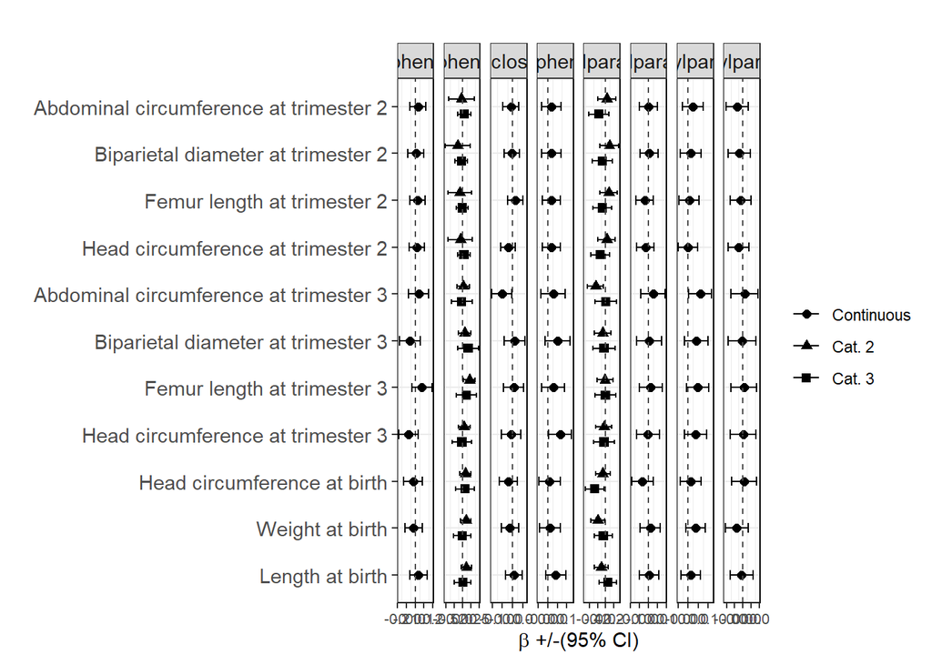

```r
PlotModel(model_cont = model_output_cont,
          model_cat = model_output_cat,
          plot_title = "",
          ncol = length(exposures_long))
```

```r
ggplot2::ggsave(here::here(path_main, "figures/Figure_1.tiff"),
                scale = 1/90,
                height = 600,
                width = 1300)
```

### FIGURE 2

Adjusted associations between pregnancy phenol concentrations and growth outcomes in utero (at trimester 2 and 3) and at birth in a sex-stratified analysis

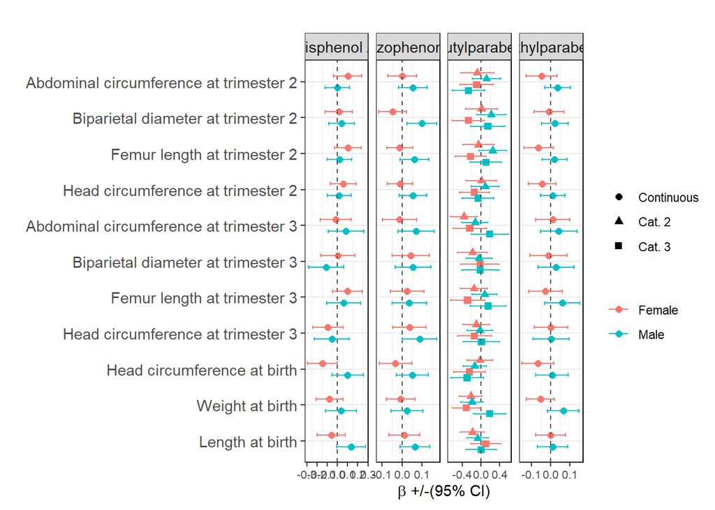

```r
model_cont <- model_output_inter_cont %>%

    # Pick only those exposures for which interactions were detected
  dplyr::filter(stringr::str_detect(exp, "BPA|BP3|ETPA"))

model_cat <- model_output_inter_cat %>%

  # Pick only those exposures for which interactions were detected
  dplyr::filter(stringr::str_detect(exp, "BUPA"))

PlotModel(model_cont = model_cont,
          model_cat = model_cat,
          plot_title = "",
          sex = TRUE,
          ncol = length(exposures_long))
```

```r
ggplot2::ggsave(here::here(path_main, "figures/Figure_2.tiff"),
                scale = 1/90,
                height = 600,
                width = 1300,
                dpi = 150)
```